# xu3LP Executive Summary

Spreek

4/19/2021

TL;DR

**DAI-USDC**: (1.000, 1.001)

**USDT-USDC**: (0.999, 1.001)

**sUSD-USDC**: (1.002, 1.010)

**sETH-ETH**: (1.002, 1.010)

**sBTC-BTC**: (1.002, 1.010)

(All pairs, but particularly synth pairs subject to change based on current market prices at time of LP program inception)

## Introduction

First, a few words about the approach I chose. The xu3LP tokens are intended to provide passive and consistent fee income from providing stablecoin liquidity in as efficient a manner as possible.

So we want to keep necessary rebalances to a minimum, and we don’t necessarily want to excessively speculate on stablecoin pegs. Of course, we will have to make some opinionated guesses about prices, and as we will see that biasing our liquidity towards 1 will give us better results.

Something important to understand is that uniswap liquidity *heavily* rewards concentrating your liquidity, so it is natural to feel like the recommended ranges are too narrow. Where possible I have aimed for consistency over higher averages, but you may still feel uncomfortable with it.

## Model

Our goal will be to optimize the fee share which I define as the $\frac{\text{Volume While Inside Range (a, b) * Amplification Factor(a,b)}}{\text{All Volume}}$ . You can think of it as roughly how much additional fees you would earn LPing in range (a,b) in a pool where everyone else provided Uniswap v2 style liquidity across from 0 to infinity. The amplification factor is $\frac{1}{(1-({\frac{b}{a}})^{0.25})}$ and reflects how many times more concentrated your liquidity is compared to a uniswap v2 LP.

We will set our range informed by historical data in two stages. Step 1 is to select a Center (broadly speaking, some combination of where price is and where we expect it to go) and then Step 2 is to select a spread (i.e. how wide the range should be).

I opted for a two parameter model, where the spread S is one parameter, and the center is determined as:

$\text{Center} = \lambda + (1-\lambda) * \text{current market price}$

In other words, $\lambda$ determines how much we shrink the market price closer to the peg. If $\lambda = 0$ then we use only the current price. If $\lambda = 1$ then we set the center at 1 regardless of the current market price. If $\lambda = 0.5$ we set the center at the midpoint between 1 and the current market price. The current market price can be taken as either the last close or some sort of short term TWAP or VWAP. Because of limitations of the curve API, I used the close price.

Once we have a spread S, and a center P, we will select the tick range closest to $(P-\frac{S}{2}, P + \frac{S}{2})$

## Fitting parameters

In order to compare different combinations of $(S, \lambda)$, historical price data from Curve.fi API was used. To avoid overfitting, the following cross validation procedure was used:

Given ($\lambda$, S) and a starting date D, first, calculate the center P. Next, using historical price and volume data, we calculate fee share of the range $(P - \frac{S}{2}, P + \frac{S}{2})$ over the next N days.

Then we compare results looking ahead N days from all possible starting dates. We would like to see both a good average performance and reasonably consistent results.

## Limitations

I didn’t directly consider impermanent loss for a few reasons: 1) for stablecoin pairs with our assumptions, it should be quite minimal compared to fees and 2) it isn’t possible to directly compare the tradeoff between IL risk and fee returns without a good estimate of how large fee returns will be. At time of writing, before uniswap v3 is even released, estimating this even to an order of magnitude is extremely difficult.

The other major limitation is that the objective variable here does not take into account the dynamic nature of the uniswap v3 market. Clearly, other participants will structure their liquidity in such a way as to maximize their own returns as well, and this is likely to cause some changes to market structure as well as to expected returns.

I did try to make recommendations that are aware of these limitations and tried to err on the side of being safe with respect to them. After there is more uniswap v3 data, these questions should be revisited.

## Results

### DAI-USDC

Data from the curve 3pool after the introduction of the Dai Peg Stability Module (December 2020) was used. There was a clear breakpoint in the data at that point, and my belief is that data after December 2020 will be more predictive going forward. Due to the limited data, a 15 day lookahead period was used; however the recommendation was not sensitive to this choice.

**Lambda = 0.6, S = 0.001 or 0.002**

**Likely range: (1.000,1.001)**

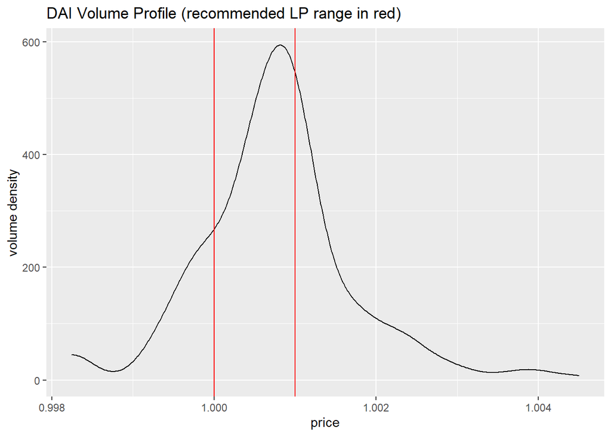

Backtesting verifies that the optimal strategy will involve a tight range near to 1. Given constraints of the tick ranges, we can choose between 3 primary strategies:

**Strategy A = (1,1.001)**

**Strategy B = (0.999,1.001)**

**Strategy C = (1,1.002)**

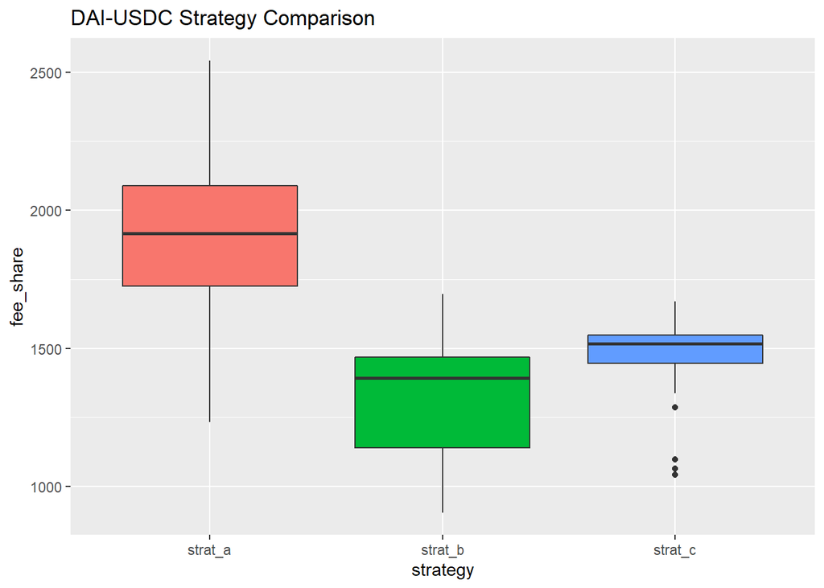

As we can see, strategy A clearly performs the best in sample, although it is somewhat higher risk than the other two. Still, I think it is clear enough that it should be preferred.

### USDT-USDC

Data from the curve 3pool was used with a lookahead of 30 days.

**Lambda = 0.5, S = 0.001 or 0.002**

**Likely range: (0.999,1.001)**

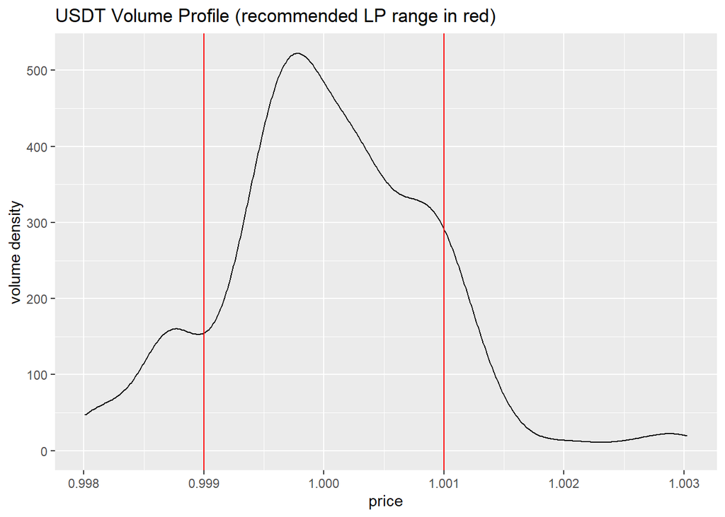

We see a similar shaped volume profile heavily concentrated around 1. Preliminary backtests confirmed that a concentrated tick range will be best. So next we compared the two major choices:

**Strategy A: (0.999, 1)**

**Strategy B: (0.999, 1.001)**

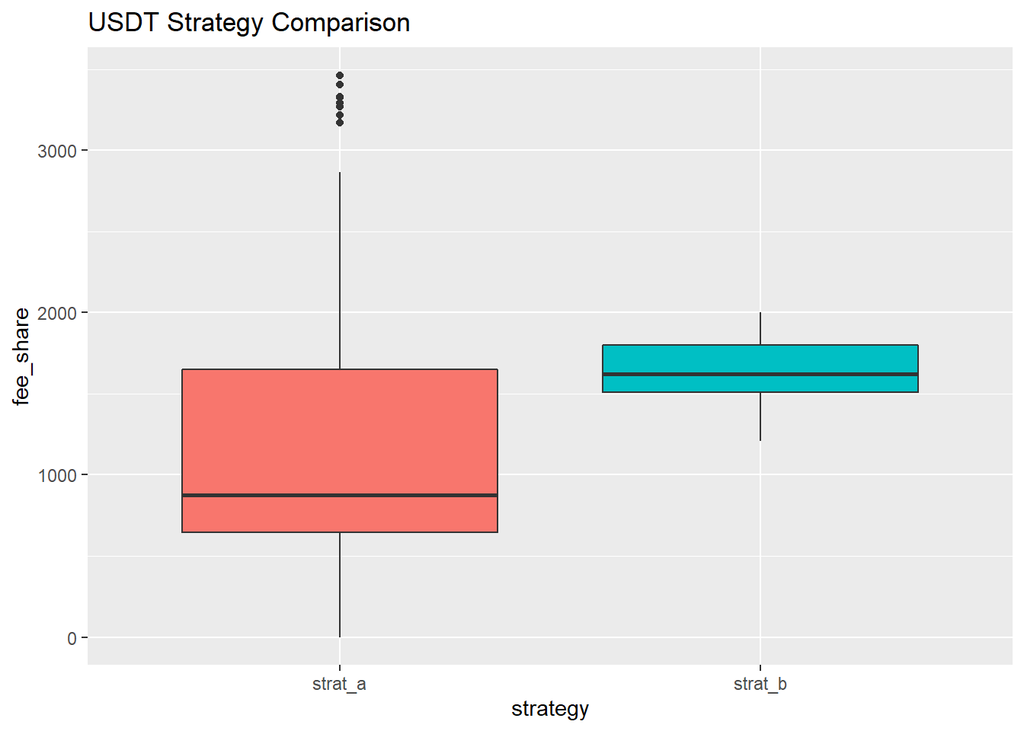

This time, we see that Strategy B with a wider range on both sides of 1 performs better and has less variance. So we will go with that one.

### sUSD-USDC / sETH-ETH / sBTC-BTC

Data was collected from Curve API and backtests used a look ahead of 60 days. I used a longer look ahead here because sUSD curve pool is one of the oldest. Also, the synth time series is a bit less stationary than the other pairs examined here and I wanted to make sure that any strategy chosen was less likely to become obsolete quickly.

Recommendation

**Lambda = 0.65, S = 0.008**

**Range at time of writing: (1.002, 1.010)**

The synth pairs are significantly more volatile than the pairs examined above. This means that a wider spread is likely called for. Very small ranges still tended to have the highest *mean* fee share but they had substantially higher risk of earning very little or nothing at all. In practice, this would also manifest in higher impermanent loss.

While there are some differences in the volume distribution of the 3 different pairs here, they were not different enough to where I wanted to choose 3 different frameworks for the 3 different tokens. It would likely be fine to select the same range for all 3 pairs, although using the parameters and choosing 3 different but similar ranges also works.

I did a grid search across values of lambda and S, which did not ultimately find a conclusive best choice. I will present three different well performing strategies below and explain why I chose the one I did.

**Strategy A: $\lambda = 0.65, S = 0.002$**

**Strategy B: $\lambda = 0.65, S = 0.008$**

**Strategy C: $\lambda = 0.35, S = 0.014$**

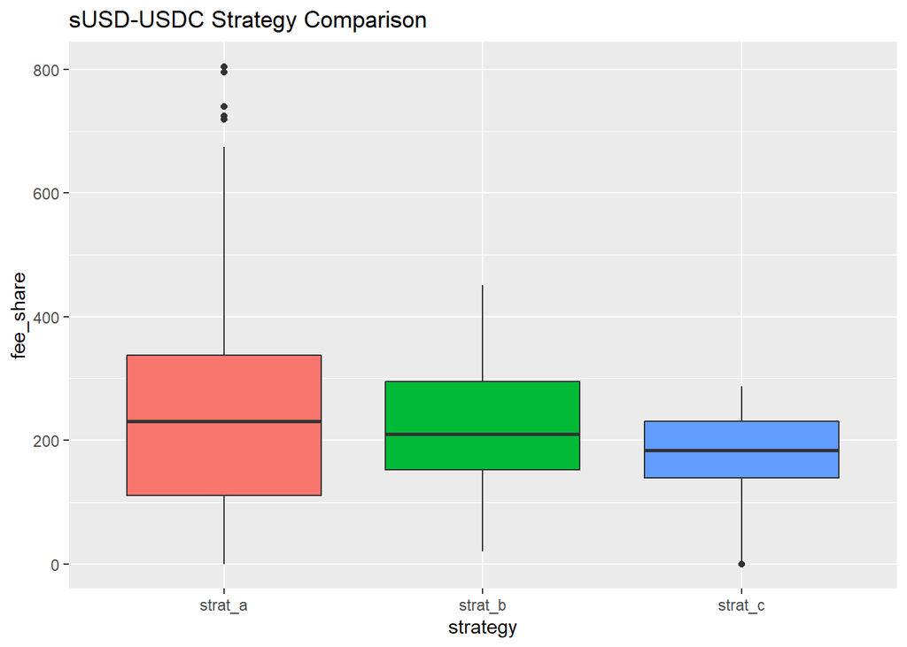

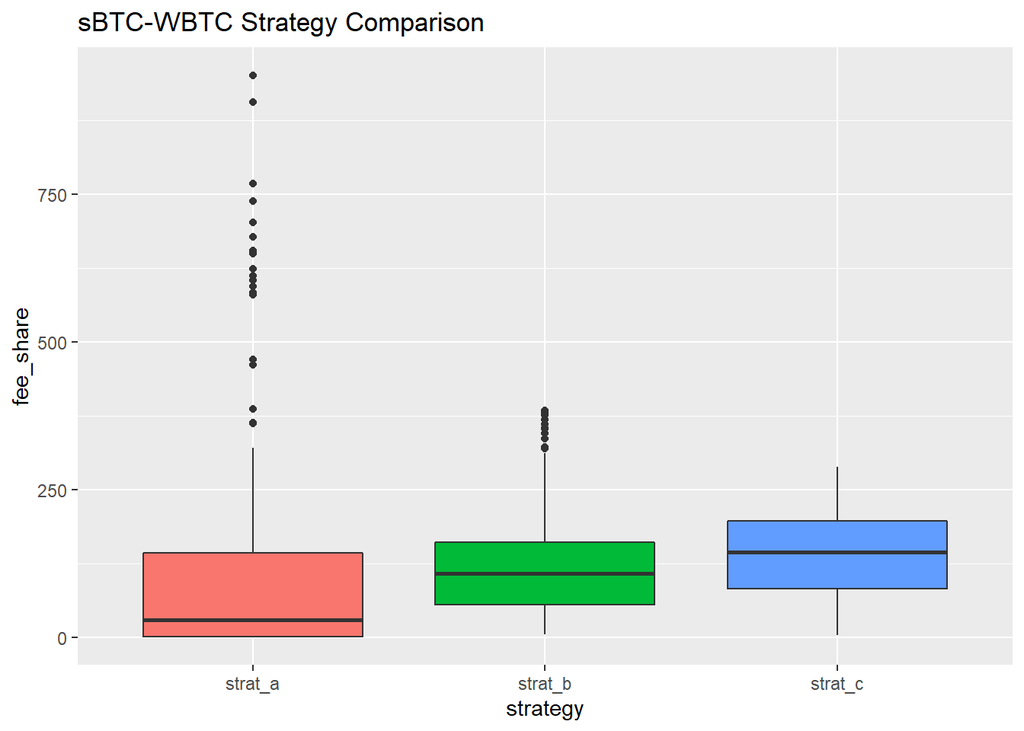

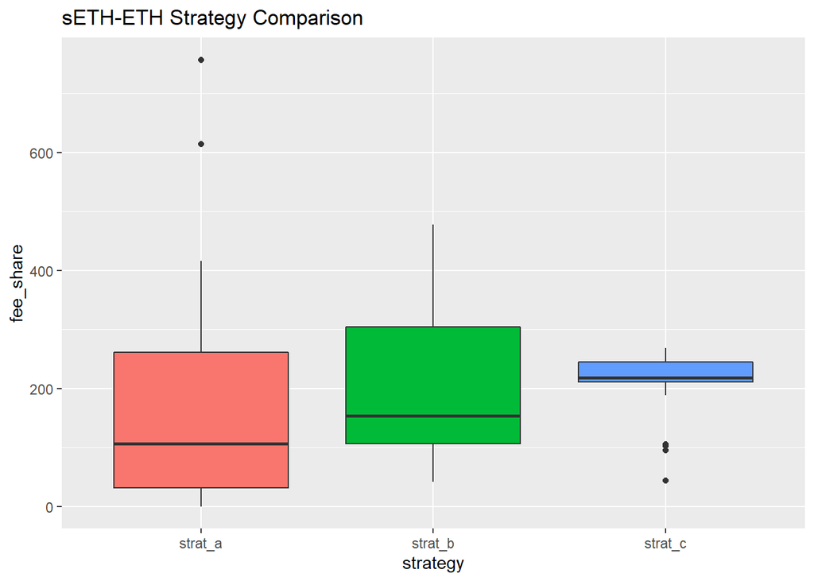

I chose strategy B because it performed relatively solidly in all aspects and on all 3 similar assets. It also yields a sensible looking strategy that should be robust to impermanent loss and shouldn’t have to rebalance extremely often.

Of course, many other choices of these parameters would work. Below, I show a quick sanity check of the proposed range vs the historical volume profile.

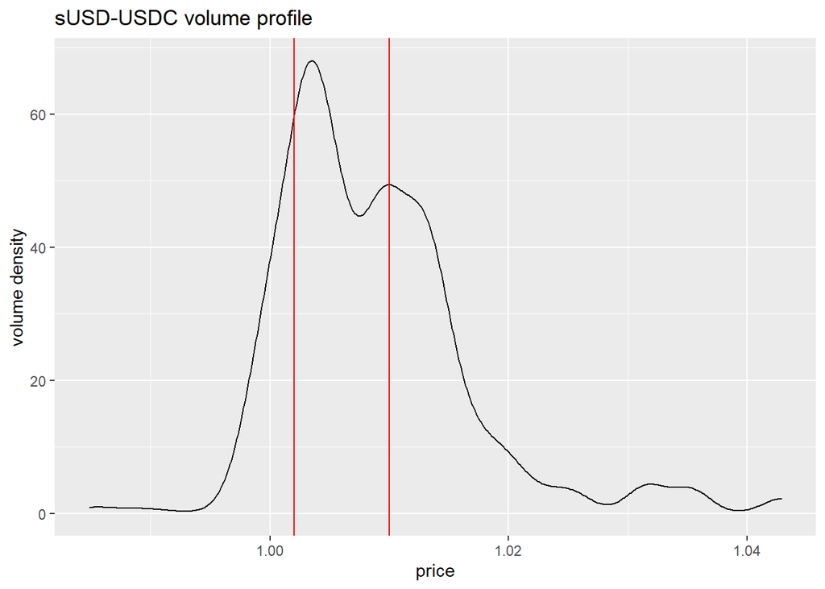

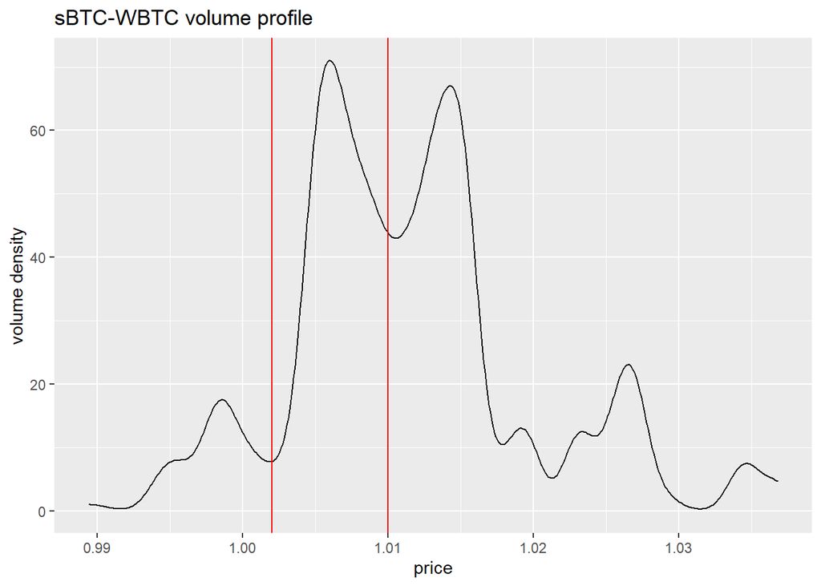

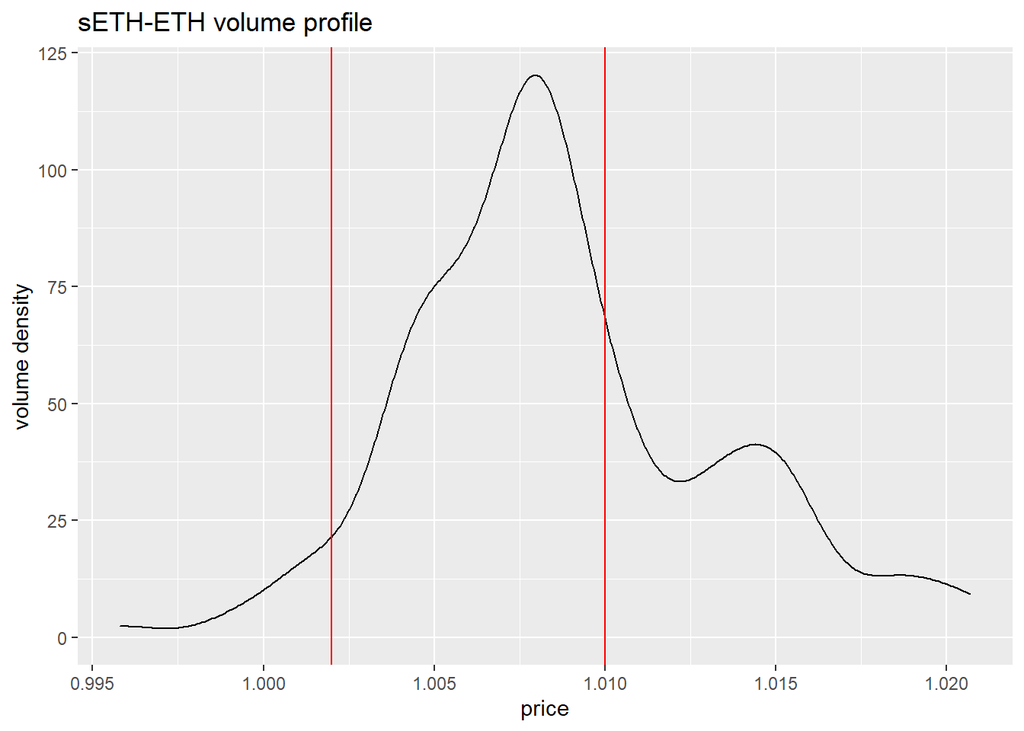

I also want to note that [SIP-112](https://sips.synthetix.io/sips/sip-112) has been approved and is currently in the process of being implemented. This is similar to the Peg Stability Module that successfully brought DAI to near peg for several months now. So depending on when this gets implemented and what changes in synth price action is observed, we may see a new regime closer to DAI-USDC today than to Synth volatility in the past.

With that in mind, it seems likely that these will have to be rebalanced at some point anyway. So picking something relatively unlikely to be a disaster was a priority over picking the most optimized for highest expected return that would have a 10% chance of earning nothing. If/when we have better data on how uniswap v3 plays out in practice and better idea of how synth pairs price action will develop, this range can be reevaluated.

## Conclusions

A quick and dirty model for a new stablecoin pair might look something like taking $\lambda = 0.5$ and $S = 1.5\sigma$ where sigma is the standard deviation of prices.

Future work once more data is available should also consider the tradeoff between risks of IL and fee collection, game theory aspects of competing with other liquidity providers, and changes to stablecoin peg dynamics as the result of governance.